# BUSINESS CASE

- I am a Data analyst at FestMan Company which owns a chain of hotels and I will help the company get insights from their Hotel bookings data from 2010 to 2019 using Python.

## Business Task

- The executive team wants me to use data to answer some business quesions

### Business Questions

- **Year**
> - How has the number of booking changed in years.
> - How has the amount of discount given varied by years.
> - How has the profit generated varied by years.
- **Month**
> - How doies the number of bookings vary by month.
> - How does the amount of discount given vary by months.
> - How does the profit generated vary by months.
- **Hotel**
> - Which hotel satisfies customers the most.
> - Which hotel generates the most profit.
> - Which hotel gives the most discount.
> - Which hotel records the highest number of bookings.
- **Gender**
> - Which gender of customer patronize the hotels.
> - Which gender of customer does the hotel make more profit from.
> - Which gender stays averagely for more days
> - Which hender Which gender enjoys the most discounts.
- **Payment options**
> - Which bank does most of our customers use.
> - Which payment mode does most of our customers use.
- **Country**
> - Which origin country does mot customers come from
> - Whuch destination country does most customers go to

# DATA WRANGLING

## Importing Libraries

```python
import pandas as pd
import numpy as np
import matplotlib.pyplot as plt
import seaborn as sns
```

## Data Gathering

```python
# Read the excel file
df = pd.read_excel('hostel_booking.xlsx')
```

## Data Assessment 1- Visual

```python
df.Year.nunique()
```

```
10
```

```python
#Check the first 10 rows
df.head(5)
```

|  | Booking ID | Date of Booking | Year | Time | Customer ID | Gender | Age | Origin Country | State | Location | ... | Hotel Name | Hotel Rating | Payment Mode | Bank Name | No. Of Days.1 | Rooms.1 | Booking Price[SGD] | Discount | GST | Profit Margin |
| --- | --- | --- | --- | --- | --- | --- | --- | --- | --- | --- | --- | --- | --- | --- | --- | --- | --- | --- | --- | --- | --- |
| 0 | DDMY00001 | 2010-01-01 | 2010 | 10:49:40 | MY00001 | Male | 42 | Malaysia | Johor | Iskandar Puteri | ... | Hotel Triton | 4.3 | Wallet | United Overseas Bank (UOB) | 8 | 1 | 243 | 0.01 | 0.07 | 0.25 |
| 1 | DDID00002 | 2010-01-01 | 2010 | 09:19:47 | ID00001 | Female | 44 | Indonesia | Ciawi | West Java | ... | Enchanted Isle | 4.2 | Wallet | EZ-Link | 1 | 2 | 312 | 0.00 | 0.07 | 0.24 |
| 2 | DDSG00003 | 2010-01-01 | 2010 | 11:52:56 | SG00001 | Female | 31 | Singapore | Central | Rochor | ... | Seacoast Hotel | 4.5 | Credit Card | Grab | 7 | 2 | 338 | 0.19 | 0.07 | 0.20 |
| 3 | DDSG00004 | 2010-01-01 | 2010 | 13:44:40 | SG00002 | Male | 28 | Singapore | North | Yishun | ... | Night In Paradise | 4.2 | Debit Card | DBS Paylah | 4 | 2 | 254 | 0.19 | 0.07 | 0.13 |
| 4 | DDKH00005 | 2010-01-01 | 2010 | 05:38:26 | KH00001 | Male | 44 | Cambodia | Phnom Trop | Pursat | ... | Tiny Digs Hotel | 4.6 | Wallet | Bank of Singapore (BOS) | 3 | 3 | 313 | 0.15 | 0.07 | 0.17 |

5 rows × 27 columns

```python
#Check the dimensions
df.tail(5)
```

|  | Booking ID | Date of Booking | Year | Time | Customer ID | Gender | Age | Origin Country | State | Location | ... | Hotel Name | Hotel Rating | Payment Mode | Bank Name | No. Of Days.1 | Rooms.1 | Booking Price[SGD] | Discount | GST | Profit Margin |
| --- | --- | --- | --- | --- | --- | --- | --- | --- | --- | --- | --- | --- | --- | --- | --- | --- | --- | --- | --- | --- | --- |
| 66530 | DDSG66531 | 2019-12-31 | 2019 | 23:36:16 | SG12034 | Female | 42 | Singapore | Central | Orchard | ... | Silver Cloud Inn | 4.3 | Wallet | Grab | 4 | 2 | 182 | 0.23 | 0.07 | 0.24 |
| 66531 | DDSG66532 | 2019-12-31 | 2019 | 14:41:01 | SG12035 | Female | 54 | Singapore | Central | Geylang | ... | The Elet | 4.2 | COD | DBS Paylah | 4 | 2 | 125 | 0.06 | 0.07 | 0.19 |
| 66532 | DDSG66533 | 2019-12-31 | 2019 | 19:11:16 | SG12036 | Female | 57 | Singapore | Central | Downtown Core | ... | The Elet | 4.4 | Debit Card | EZ-Link | 1 | 4 | 318 | 0.02 | 0.07 | 0.22 |
| 66533 | DDTH66534 | 2019-12-31 | 2019 | 05:12:29 | TH12170 | Female | 44 | Thailand | Surat Thani | Ko Samui | ... | Sunset Lodge | 4.2 | Debit Card | HSBC | 1 | 2 | 173 | 0.14 | 0.07 | 0.25 |
| 66534 | DDVN66535 | 2019-12-31 | 2019 | 00:51:52 | VN05959 | Female | 52 | Vietnam | Pleiku | Gia Lai | ... | Coastal bay hotel | 4.3 | Internet Banking | Grab | 4 | 3 | 182 | 0.17 | 0.07 | 0.24 |

5 rows × 27 columns

**Observations**

- There is no visual error.

## Data Assessment 2- Programmatic

```python
#Let us check the rows and dimensions
df.info()
```

```
<class 'pandas.core.frame.DataFrame'>
RangeIndex: 66535 entries, 0 to 66534
Data columns (total 27 columns):
 #   Column               Non-Null Count  Dtype
---  ------               --------------  -----
 0   Booking ID           66535 non-null  object
 1   Date of Booking      66535 non-null  datetime64[ns]
 2   Year                 66535 non-null  int64
 3   Time                 66535 non-null  object
 4   Customer ID          66535 non-null  object
 5   Gender               66535 non-null  object
 6   Age                  66535 non-null  int64
 7   Origin Country       66535 non-null  object
 8   State                66535 non-null  object
 9   Location             66535 non-null  object
```

[output cut: 19 more lines]

**Observations**

> **Data issues**
> - Year is integer instead of string
> - Time is string
> - Rooms and no. of days columns were repeated

```python
# Lets have a summary statistics
df.describe()
```

|  | Year | Age | No. Of People | No. Of Days | Rooms | Hotel Rating | No. Of Days.1 | Rooms.1 | Booking Price[SGD] | Discount | GST | Profit Margin |
| --- | --- | --- | --- | --- | --- | --- | --- | --- | --- | --- | --- | --- |
| count | 66535.000000 | 66535.000000 | 66535.000000 | 66535.000000 | 66535.000000 | 66535.000000 | 66535.000000 | 66535.000000 | 66535.000000 | 66535.000000 | 6.653500e+04 | 66535.000000 |
| mean | 2015.132396 | 38.436402 | 3.995852 | 3.233787 | 2.283400 | 4.288508 | 3.233787 | 2.283400 | 214.054212 | 0.125473 | 7.000000e-02 | 0.188815 |
| std | 2.885649 | 11.556566 | 2.000116 | 3.377939 | 1.031154 | 0.275520 | 3.377939 | 1.031154 | 108.127280 | 0.075115 | 2.774191e-14 | 0.052766 |
| min | 2010.000000 | 19.000000 | 1.000000 | 1.000000 | 1.000000 | 3.300000 | 1.000000 | 1.000000 | 35.000000 | 0.000000 | 7.000000e-02 | 0.100000 |
| 25% | 2013.000000 | 28.000000 | 2.000000 | 1.000000 | 1.000000 | 4.200000 | 1.000000 | 1.000000 | 125.000000 | 0.060000 | 7.000000e-02 | 0.140000 |
| 50% | 2015.000000 | 38.000000 | 4.000000 | 2.000000 | 2.000000 | 4.300000 | 2.000000 | 2.000000 | 199.000000 | 0.130000 | 7.000000e-02 | 0.200000 |
| 75% | 2018.000000 | 48.000000 | 6.000000 | 4.000000 | 3.000000 | 4.500000 | 4.000000 | 3.000000 | 293.000000 | 0.190000 | 7.000000e-02 | 0.230000 |
| max | 2019.000000 | 58.000000 | 7.000000 | 97.000000 | 4.000000 | 4.700000 | 97.000000 | 4.000000 | 578.000000 | 0.250000 | 7.000000e-02 | 0.300000 |

**Observations**

- The age range is from (19-58)
- People stay for an average of 3 days

## Data Cleaning

### 1) Year Column

- Lets turn the column to a string

```python
#Lets change it to string
df['Year'] = df.Year.apply(str)
#Lets confirm
df.info()
```

```
<class 'pandas.core.frame.DataFrame'>
RangeIndex: 66535 entries, 0 to 66534
Data columns (total 27 columns):
 #   Column               Non-Null Count  Dtype
---  ------               --------------  -----
 0   Booking ID           66535 non-null  object
 1   Date of Booking      66535 non-null  datetime64[ns]
 2   Year                 66535 non-null  object
 3   Time                 66535 non-null  object
 4   Customer ID          66535 non-null  object
 5   Gender               66535 non-null  object
 6   Age                  66535 non-null  int64
 7   Origin Country       66535 non-null  object
 8   State                66535 non-null  object
 9   Location             66535 non-null  object
```

[output cut: 19 more lines]

### 2) Drop repeated columns

```python
#Drop repeating columns
df = df.drop(['Rooms.1', 'No. Of Days.1'], axis=1)
```

```python
df.head(5)
df.shape
```

```
(66535, 25)
```

### 3) Columns to lowercase

```python
df.columns = df.columns.str.lower()
df.columns
```

```
Index(['booking id', 'date of booking', 'year', 'time', 'customer id',
       'gender', 'age', 'origin country', 'state', 'location',
       'destination country', 'destination city', 'no. of people',
       'check-in date', 'no. of days', 'check-out date', 'rooms', 'hotel name',
       'hotel rating', 'payment mode', 'bank name', 'booking price[sgd]',
       'discount', 'gst', 'profit margin'],
      dtype='object')
```

### 4) Convert columns to standard naming format

```python
df.columns = df.columns.str.replace(' ', '_')
df.columns = df.columns.str.replace('-', '_')
df.columns = df.columns.str.replace('.', '')
df.columns
```

```
Index(['booking_id', 'date_of_booking', 'year', 'time', 'customer_id',
       'gender', 'age', 'origin_country', 'state', 'location',
       'destination_country', 'destination_city', 'no_of_people',
       'check_in_date', 'no_of_days', 'check_out_date', 'rooms', 'hotel_name',
       'hotel_rating', 'payment_mode', 'bank_name', 'booking_price[sgd]',
       'discount', 'gst', 'profit_margin'],
      dtype='object')
```

### 5) Renaming Booking Price column

```python
df.rename(columns = {'booking_price[sgd]' : 'booking_price'}, inplace=True)
df.columns
```

```
Index(['booking_id', 'date_of_booking', 'year', 'time', 'customer_id',
       'gender', 'age', 'origin_country', 'state', 'location',
       'destination_country', 'destination_city', 'no_of_people',
       'check_in_date', 'no_of_days', 'check_out_date', 'rooms', 'hotel_name',
       'hotel_rating', 'payment_mode', 'bank_name', 'booking_price',
       'discount', 'gst', 'profit_margin'],
      dtype='object')
```

### 5) Create Month Column

```python
df['month'] = df.date_of_booking.dt.month_name()
df['month_no'] = df.date_of_booking.dt.month
df.columns
```

```
Index(['booking_id', 'date_of_booking', 'year', 'time', 'customer_id',
       'gender', 'age', 'origin_country', 'state', 'location',
       'destination_country', 'destination_city', 'no_of_people',
       'check_in_date', 'no_of_days', 'check_out_date', 'rooms', 'hotel_name',
       'hotel_rating', 'payment_mode', 'bank_name', 'booking_price',
       'discount', 'gst', 'profit_margin', 'month', 'month_no'],
      dtype='object')
```

```python
df.head(5)
```

|  | booking_id | date_of_booking | year | time | customer_id | gender | age | origin_country | state | location | ... | hotel_name | hotel_rating | payment_mode | bank_name | booking_price | discount | gst | profit_margin | month | month_no |
| --- | --- | --- | --- | --- | --- | --- | --- | --- | --- | --- | --- | --- | --- | --- | --- | --- | --- | --- | --- | --- | --- |
| 0 | DDMY00001 | 2010-01-01 | 2010 | 10:49:40 | MY00001 | Male | 42 | Malaysia | Johor | Iskandar Puteri | ... | Hotel Triton | 4.3 | Wallet | United Overseas Bank (UOB) | 243 | 0.01 | 0.07 | 0.25 | January | 1 |
| 1 | DDID00002 | 2010-01-01 | 2010 | 09:19:47 | ID00001 | Female | 44 | Indonesia | Ciawi | West Java | ... | Enchanted Isle | 4.2 | Wallet | EZ-Link | 312 | 0.00 | 0.07 | 0.24 | January | 1 |
| 2 | DDSG00003 | 2010-01-01 | 2010 | 11:52:56 | SG00001 | Female | 31 | Singapore | Central | Rochor | ... | Seacoast Hotel | 4.5 | Credit Card | Grab | 338 | 0.19 | 0.07 | 0.20 | January | 1 |
| 3 | DDSG00004 | 2010-01-01 | 2010 | 13:44:40 | SG00002 | Male | 28 | Singapore | North | Yishun | ... | Night In Paradise | 4.2 | Debit Card | DBS Paylah | 254 | 0.19 | 0.07 | 0.13 | January | 1 |
| 4 | DDKH00005 | 2010-01-01 | 2010 | 05:38:26 | KH00001 | Male | 44 | Cambodia | Phnom Trop | Pursat | ... | Tiny Digs Hotel | 4.6 | Wallet | Bank of Singapore (BOS) | 313 | 0.15 | 0.07 | 0.17 | January | 1 |

5 rows × 27 columns

### 6) Calculate the Net booking price column.

```python
df['discount_amount']  = df['booking_price'] * df['discount']
df['tax_amount'] = df['booking_price'] * df['gst']
df['net_booking_price'] = df['booking_price'] - (df['tax_amount'] + df['discount_amount'])
```

```python
df.head(5)
```

|  | booking_id | date_of_booking | year | time | customer_id | gender | age | origin_country | state | location | ... | bank_name | booking_price | discount | gst | profit_margin | month | month_no | discount_amount | tax_amount | net_booking_price |
| --- | --- | --- | --- | --- | --- | --- | --- | --- | --- | --- | --- | --- | --- | --- | --- | --- | --- | --- | --- | --- | --- |
| 0 | DDMY00001 | 2010-01-01 | 2010 | 10:49:40 | MY00001 | Male | 42 | Malaysia | Johor | Iskandar Puteri | ... | United Overseas Bank (UOB) | 243 | 0.01 | 0.07 | 0.25 | January | 1 | 2.43 | 17.01 | 223.56 |
| 1 | DDID00002 | 2010-01-01 | 2010 | 09:19:47 | ID00001 | Female | 44 | Indonesia | Ciawi | West Java | ... | EZ-Link | 312 | 0.00 | 0.07 | 0.24 | January | 1 | 0.00 | 21.84 | 290.16 |
| 2 | DDSG00003 | 2010-01-01 | 2010 | 11:52:56 | SG00001 | Female | 31 | Singapore | Central | Rochor | ... | Grab | 338 | 0.19 | 0.07 | 0.20 | January | 1 | 64.22 | 23.66 | 250.12 |
| 3 | DDSG00004 | 2010-01-01 | 2010 | 13:44:40 | SG00002 | Male | 28 | Singapore | North | Yishun | ... | DBS Paylah | 254 | 0.19 | 0.07 | 0.13 | January | 1 | 48.26 | 17.78 | 187.96 |
| 4 | DDKH00005 | 2010-01-01 | 2010 | 05:38:26 | KH00001 | Male | 44 | Cambodia | Phnom Trop | Pursat | ... | Bank of Singapore (BOS) | 313 | 0.15 | 0.07 | 0.17 | January | 1 | 46.95 | 21.91 | 244.14 |

5 rows × 30 columns

### 7) Calculate Profit column

```python
df['profit'] = df['net_booking_price'] * df['profit_margin']
```

```python
df.head(5)
```

|  | booking_id | date_of_booking | year | time | customer_id | gender | age | origin_country | state | location | ... | booking_price | discount | gst | profit_margin | month | month_no | discount_amount | tax_amount | net_booking_price | profit |
| --- | --- | --- | --- | --- | --- | --- | --- | --- | --- | --- | --- | --- | --- | --- | --- | --- | --- | --- | --- | --- | --- |
| 0 | DDMY00001 | 2010-01-01 | 2010 | 10:49:40 | MY00001 | Male | 42 | Malaysia | Johor | Iskandar Puteri | ... | 243 | 0.01 | 0.07 | 0.25 | January | 1 | 2.43 | 17.01 | 223.56 | 55.8900 |
| 1 | DDID00002 | 2010-01-01 | 2010 | 09:19:47 | ID00001 | Female | 44 | Indonesia | Ciawi | West Java | ... | 312 | 0.00 | 0.07 | 0.24 | January | 1 | 0.00 | 21.84 | 290.16 | 69.6384 |
| 2 | DDSG00003 | 2010-01-01 | 2010 | 11:52:56 | SG00001 | Female | 31 | Singapore | Central | Rochor | ... | 338 | 0.19 | 0.07 | 0.20 | January | 1 | 64.22 | 23.66 | 250.12 | 50.0240 |
| 3 | DDSG00004 | 2010-01-01 | 2010 | 13:44:40 | SG00002 | Male | 28 | Singapore | North | Yishun | ... | 254 | 0.19 | 0.07 | 0.13 | January | 1 | 48.26 | 17.78 | 187.96 | 24.4348 |
| 4 | DDKH00005 | 2010-01-01 | 2010 | 05:38:26 | KH00001 | Male | 44 | Cambodia | Phnom Trop | Pursat | ... | 313 | 0.15 | 0.07 | 0.17 | January | 1 | 46.95 | 21.91 | 244.14 | 41.5038 |

5 rows × 31 columns

### 8) Saving our clean data

```python
df.to_csv('clean_hotel_booking', index=False)
```

### 9) Dropping columns irrelevant for analysis

```python
df.columns
```

```
Index(['booking_id', 'date_of_booking', 'year', 'time', 'customer_id',
       'gender', 'age', 'origin_country', 'state', 'location',
       'destination_country', 'destination_city', 'no_of_people',
       'check_in_date', 'no_of_days', 'check_out_date', 'rooms', 'hotel_name',
       'hotel_rating', 'payment_mode', 'bank_name', 'booking_price',
       'discount', 'gst', 'profit_margin', 'month', 'month_no',
       'discount_amount', 'tax_amount', 'net_booking_price', 'profit'],
      dtype='object')
```

- Location has 228 unique va;lues so it is too broad for our analysis.
- State has 219 unique values so it is too broad for our analysis.
- Destination_city has 119 unique values so it is for broad for our analysis.
- Time is not a necesary column for insights so we can remove it.
- We don't need check-in and check-out days again when we have no. of days.
- We have gotten the tax_amount and the discount_amount, we can remove our margins.

```python
df.drop(['gst', 'check_in_date', 'check_out_date', 'profit_margin', 'discount','time', 'destination_city','state', 'location' ], inplace=True, axis=1)
```

```python
df
```

|  | booking_id | date_of_booking | year | customer_id | gender | age | origin_country | destination_country | no_of_people | no_of_days | ... | hotel_rating | payment_mode | bank_name | booking_price | month | month_no | discount_amount | tax_amount | net_booking_price | profit |
| --- | --- | --- | --- | --- | --- | --- | --- | --- | --- | --- | --- | --- | --- | --- | --- | --- | --- | --- | --- | --- | --- |
| 0 | DDMY00001 | 2010-01-01 | 2010 | MY00001 | Male | 42 | Malaysia | Denmark | 1 | 8 | ... | 4.3 | Wallet | United Overseas Bank (UOB) | 243 | January | 1 | 2.43 | 17.01 | 223.56 | 55.8900 |
| 1 | DDID00002 | 2010-01-01 | 2010 | ID00001 | Female | 44 | Indonesia | Colombia | 3 | 1 | ... | 4.2 | Wallet | EZ-Link | 312 | January | 1 | 0.00 | 21.84 | 290.16 | 69.6384 |
| 2 | DDSG00003 | 2010-01-01 | 2010 | SG00001 | Female | 31 | Singapore | Germany | 3 | 7 | ... | 4.5 | Credit Card | Grab | 338 | January | 1 | 64.22 | 23.66 | 250.12 | 50.0240 |
| 3 | DDSG00004 | 2010-01-01 | 2010 | SG00002 | Male | 28 | Singapore | Canada | 3 | 4 | ... | 4.2 | Debit Card | DBS Paylah | 254 | January | 1 | 48.26 | 17.78 | 187.96 | 24.4348 |
| 4 | DDKH00005 | 2010-01-01 | 2010 | KH00001 | Male | 44 | Cambodia | Kenya | 5 | 3 | ... | 4.6 | Wallet | Bank of Singapore (BOS) | 313 | January | 1 | 46.95 | 21.91 | 244.14 | 41.5038 |
| ... | ... | ... | ... | ... | ... | ... | ... | ... | ... | ... | ... | ... | ... | ... | ... | ... | ... | ... | ... | ... | ... |
| 66530 | DDSG66531 | 2019-12-31 | 2019 | SG12034 | Female | 42 | Singapore | Germany | 4 | 4 | ... | 4.3 | Wallet | Grab | 182 | December | 12 | 41.86 | 12.74 | 127.40 | 30.5760 |
| 66531 | DDSG66532 | 2019-12-31 | 2019 | SG12035 | Female | 54 | Singapore | Israel | 4 | 4 | ... | 4.2 | COD | DBS Paylah | 125 | December | 12 | 7.50 | 8.75 | 108.75 | 20.6625 |
| 66532 | DDSG66533 | 2019-12-31 | 2019 | SG12036 | Female | 57 | Singapore | Canada | 7 | 1 | ... | 4.4 | Debit Card | EZ-Link | 318 | December | 12 | 6.36 | 22.26 | 289.38 | 63.6636 |
| 66533 | DDTH66534 | 2019-12-31 | 2019 | TH12170 | Female | 44 | Thailand | Maldives | 3 | 1 | ... | 4.2 | Debit Card | HSBC | 173 | December | 12 | 24.22 | 12.11 | 136.67 | 34.1675 |
| 66534 | DDVN66535 | 2019-12-31 | 2019 | VN05959 | Female | 52 | Vietnam | Egypt | 5 | 4 | ... | 4.3 | Internet Banking | Grab | 182 | December | 12 | 30.94 | 12.74 | 138.32 | 33.1968 |

66535 rows × 22 columns

# DATA ANALYSIS

Let's perform analysis from our data to get insights

## 1) Year Analysis

### Bookings by year

```python
df.groupby('year')[['booking_id']].count()
```

| year | booking_id |
| --- | --- |
| 2010 | 4797 |
| 2011 | 5309 |
| 2012 | 5607 |
| 2013 | 5525 |
| 2014 | 5905 |
| 2015 | 6292 |
| 2016 | 6212 |
| 2017 | 8571 |
| 2018 | 8816 |
| 2019 | 9501 |

**Booking**

### Profit and discount offered by year

```python
df.groupby('year')[['profit', 'discount_amount']].sum()
```

| year | profit | discount_amount |
| --- | --- | --- |
| 2010 | 146174.3221 | 125584.69 |
| 2011 | 169776.5984 | 142164.39 |
| 2012 | 199805.9937 | 169684.60 |
| 2013 | 210657.2869 | 174867.77 |
| 2014 | 139501.8130 | 116843.03 |
| 2015 | 168524.1302 | 144423.20 |
| 2016 | 173700.2416 | 147583.19 |
| 2017 | 257339.5448 | 216223.11 |
| 2018 | 320947.9480 | 268356.59 |
| 2019 | 327621.1703 | 279834.50 |

**Profit**

- We can see a gradual increase from 2010 till 2013 but a sudden drop in 2014.
- There was a gradual increase from 2014 till 2019

**Discount**

- The same trend as observed with profit
- This implies discount is correlated with profit.

## 2) Month Analysis

### Bookings by Month

```python
df.groupby(['month_no', 'month'])[['booking_id']].count().sort_values(by='month_no')
```

| month_no | month | booking_id |
| --- | --- | --- |
| 1 | January | 5628 |
| 2 | February | 5230 |
| 3 | March | 5635 |
| 4 | April | 5410 |
| 5 | May | 5704 |
| 6 | June | 5339 |
| 7 | July | 5562 |
| 8 | August | 5733 |
| 9 | September | 5443 |
| 10 | October | 5716 |
| 11 | November | 5389 |
| 12 | December | 5746 |

**Booking**

- There is really no visible trend.

### Profit and discount offered by Month

```python
df.groupby(['month_no', 'month'])[['profit', 'discount_amount']].sum().sort_values(by='month_no')
```

| month_no | month | profit | discount_amount |
| --- | --- | --- | --- |
| 1 | January | 178580.5776 | 150252.19 |
| 2 | February | 166768.3735 | 139971.46 |
| 3 | March | 178865.5920 | 150809.66 |
| 4 | April | 172550.1679 | 145437.93 |
| 5 | May | 182783.6568 | 152239.06 |
| 6 | June | 170105.4229 | 143202.24 |
| 7 | July | 176761.6357 | 148958.30 |
| 8 | August | 181092.9079 | 154506.25 |
| 9 | September | 172541.0692 | 146547.83 |
| 10 | October | 180840.6276 | 155464.52 |
| 11 | November | 170246.5853 | 143983.89 |
| 12 | December | 182912.4326 | 154191.74 |

**Profit**

- There is no obvious trend but May and December bringing highest and February being lowest.

**Discount**

- There is no obvious trend but August and October being highest and February being lowest.

## 3) Hotel Analysis

### Top 5 Hotels by Ratings

```python
df.groupby('hotel_name')[['hotel_rating']].mean().sort_values(by='hotel_rating', ascending= False).head(5)
```

| hotel_name | hotel_rating |
| --- | --- |
| Silver Sun Bed And Breakfast | 4.372727 |
| Waldorf Astoria Hotels & Resorts | 4.357000 |
| Moonlight Motel | 4.353125 |
| The Maxwell | 4.352252 |
| Jack Summer Inn | 4.350549 |

**Ratings**

Silver Sun Bed and Breakfast have the best ratings from customers.

### Bottom 5 Hotels by Ratings

```python
df.groupby('hotel_name')[['hotel_rating']].mean().sort_values(by='hotel_rating', ascending= False).tail(5)
```

| hotel_name | hotel_rating |
| --- | --- |
| Row Hotel | 4.220721 |
| Zion Hotel | 4.219780 |
| The Corridor | 4.217073 |
| Priority Hospitality | 4.214444 |
| The Peninsula | 4.214433 |

**Rating**

- The Peninsula and Proirity have the lowest ratings from Customers.

### Top 5 Hotels by Bookings

```python
df.groupby('hotel_name')[['booking_id']].count().sort_values(by='booking_id', ascending=False).head(5)
```

| hotel_name | booking_id |
| --- | --- |
| Grand Hyatt | 221 |
| Secret Mirage | 146 |
| Enchanted Isle | 146 |
| Ace Hotel | 146 |
| Inn It To Win It | 141 |

**Bookings**

- Grand Hyatt was the most booked hotel

### Bottom 5 Hotels by Bookings

```python
df.groupby('hotel_name')[['booking_id']].count().sort_values(by='booking_id', ).head(5)
```

| hotel_name | booking_id |
| --- | --- |
| The Cottage Motel | 73 |
| Simply Charmed B&B | 75 |
| Star of Africa B&B | 76 |
| Hotel Minute Masti | 81 |
| The Corridor | 82 |

**Bookings**

- These are the least booked hotel

### Top 5 Hotels by Profits

```python
df.groupby('hotel_name')[['profit']].sum().sort_values(by='profit', ascending=False).head(5)
```

| hotel_name | profit |
| --- | --- |
| Grand Hyatt | 7164.2006 |
| Bourbon Bliss | 5063.8494 |
| Secret Mirage | 5053.4789 |
| Enchanted Isle | 4981.1835 |
| Reefs Resort & Club | 4767.2189 |

**Profit**

- The most profit was made by Grand hyatt

### Bottom 5 Hotels by Profits

```python
df.groupby('hotel_name')[['profit']].sum().sort_values(by='profit').head(5)
```

| hotel_name | profit |
| --- | --- |
| Simply Charmed B&B | 2041.8247 |
| The Cottage Motel | 2103.9251 |
| Hotel Minute Masti | 2324.7546 |
| The Hay-Adams | 2487.2836 |
| Star of Africa B&B | 2508.8298 |

**Profit**

- These are the Hotels that made the least profits.

### Top 5 Hotels by Discount Offered.

```python
df.groupby('hotel_name')[['discount_amount']].sum().sort_values(by='discount_amount', ascending=False).head(5)
```

| hotel_name | discount_amount |
| --- | --- |
| Grand Hyatt | 5969.06 |
| Secret Mirage | 4278.54 |
| The New Yorker | 4207.83 |
| Utopia Inn | 4091.36 |
| Inn It To Win It | 4055.28 |

**Discounts**

- The most discounts were given by Grand Hyatt

### Bottom 5 Hotels by Discount Offered.

```python
df.groupby('hotel_name')[['discount_amount']].sum().sort_values(by='discount_amount').head(5)
```

| hotel_name | discount_amount |
| --- | --- |
| Prestige Proga Inn | 1769.66 |
| The Cottage Motel | 1782.13 |
| The Mutiny Hotel | 1782.23 |
| Simply Charmed B&B | 1883.60 |
| Priority Hospitality | 1898.07 |

**Discounts**

- These are the Hotels that gave the least discount.

## 4) Gender Analysis

### Bookings by Gender

```python
df.groupby('gender')[['booking_id']].count()
```

| gender | booking_id |
| --- | --- |
| Female | 33387 |
| Male | 33148 |

**Bookings**

- We have an approximately gender balanced patronage

### Number of days stayed, profit and discount offered by gender

```python
df.groupby('gender')[['no_of_days', 'profit', 'discount_amount']].sum()
```

| gender | no_of_days | profit | discount_amount |
| --- | --- | --- | --- |
| Female | 107598 | 1.059272e+06 | 904959.68 |
| Male | 107562 | 1.054777e+06 | 880605.39 |

**Number of Days**

- This distribution is approximately balanced

**Profit**

- This distribution is approximately balanced

**Discount**

- This distribution is approximately balanced

## 5) Analysis of Payment Options

### Bookings and profit by Customer banks

#### BOOKINGS

```python
df.groupby('bank_name')[['booking_id']].count().sort_values(by='booking_id', ascending=False)
```

| bank_name | booking_id |
| --- | --- |
| United Overseas Bank (UOB) | 7500 |
| Cash | 7490 |
| Bank of Singapore (BOS) | 7466 |
| DBS Bank | 7466 |
| HSBC | 7376 |
| DBS Paylah | 7330 |
| CITI Bank | 7322 |
| Grab | 7304 |
| EZ-Link | 7281 |

**Bookings**

- There is an approxiate equal bank usage with United Overseas Bank being highest and EZ-Link being lowest

#### PROFIT

```python
df.groupby('bank_name')[['profit']].sum().sort_values(by='profit', ascending=False)
```

| bank_name | profit |
| --- | --- |
| Cash | 239932.5181 |
| United Overseas Bank (UOB) | 239668.2146 |
| Bank of Singapore (BOS) | 237576.7380 |
| DBS Bank | 236020.8415 |
| Grab | 232868.5266 |
| EZ-Link | 232668.0086 |
| DBS Paylah | 232564.4051 |
| HSBC | 231989.3823 |
| CITI Bank | 230760.4142 |

**Profit**

- There is an approximately equal profit from all banks

#### DISCOUNT

```python
df.groupby('bank_name')[['discount_amount']].sum().sort_values(by='discount_amount', ascending=False)
```

| bank_name | discount_amount |
| --- | --- |
| Cash | 201542.15 |
| United Overseas Bank (UOB) | 201522.98 |
| DBS Bank | 200373.73 |
| Bank of Singapore (BOS) | 199420.51 |
| Grab | 199411.58 |
| DBS Paylah | 198132.49 |
| CITI Bank | 195571.09 |
| EZ-Link | 195327.33 |
| HSBC | 194263.21 |

**Discount**

- There is an approximately equal discount given to users from all banks

### Bookings and profit by Customer's payment mode

#### BOOKINGS

```python
df.groupby('payment_mode')[['booking_id']].count().sort_values(by='payment_mode', ascending=False)
```

| payment_mode | booking_id |
| --- | --- |
| Wallet | 13314 |
| Internet Banking | 13445 |
| Debit Card | 13363 |
| Credit Card | 13265 |
| COD | 13148 |

**Bookings**

- There is an approximately equal payment mode usage

#### PROFIT

```python
df.groupby('payment_mode')[['profit']].sum().sort_values(by='profit', ascending=False)
```

| payment_mode | profit |
| --- | --- |
| Wallet | 425085.0776 |
| Internet Banking | 425019.9488 |
| Debit Card | 422988.6175 |
| Credit Card | 422510.3337 |
| COD | 418445.0714 |

**Profit**

- There is an approximately equal profit generation.

#### DISCOUNT

```python
df.groupby('payment_mode')[['discount_amount']].sum().sort_values(by='discount_amount', ascending=False)
```

| payment_mode | discount_amount |
| --- | --- |
| Wallet | 361432.28 |
| Internet Banking | 361342.57 |
| Credit Card | 358651.80 |
| Debit Card | 353588.34 |
| COD | 350550.08 |

**Discount**

- There is an approximately equal discount given

## 6) Analysis by Origin and Destination Countries

### Bookings by Origin Country

```python
df.groupby('origin_country')[['booking_id']].count().sort_values(by='booking_id', ascending=False)
```

| origin_country | booking_id |
| --- | --- |
| Thailand | 12170 |
| Malaysia | 12049 |
| Singapore | 12036 |
| Indonesia | 11986 |
| Philippines | 6383 |
| Vietnam | 5959 |
| Cambodia | 5952 |

**Origin Country**

- We have the bulk of customers from Thailand, Malaysia and Singapore.
- We have the lowest customers coming from Vietnam and Cambodia.

### Bookings by destiantion country.

```python
df.groupby('destination_country')[['booking_id']].count().sort_values(by='booking_id', ascending=False)
```

| destination_country | booking_id |
| --- | --- |
| New Zealand | 3447 |
| Nepal | 3446 |
| Egypt | 3422 |
| Colombia | 3408 |
| China | 3391 |
| Denmark | 3375 |
| Israel | 3356 |
| France | 3346 |
| Iceland | 3344 |
| Italy | 3340 |
| Canada | 3331 |
| Ireland | 3316 |
| Germany | 3300 |
| India | 3290 |
| Maldives | 3265 |
| Mexico | 3257 |
| Japan | 3255 |
| Brazil | 3241 |
| Kenya | 3233 |
| Iran | 3172 |

**DestinationCountry**

- We have an approximate equal distribution of our Customers destination country with New Zealand being the highest and Iran being the lowest

# DATA VISUALIZATION

## 1) Year Analysis

### Bookings by year

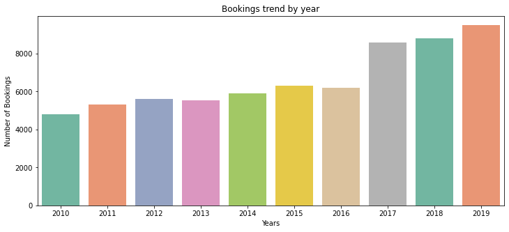

```python
plt.figure(figsize = (12,5))

year_analysis =sns.countplot(
    x = "year",
    data = df,
    palette= sns.color_palette("Set2")


)

year_analysis.set(xlabel  = "Years", ylabel = "Number of Bookings",title = "Bookings trend by year");
```

### Profit by year

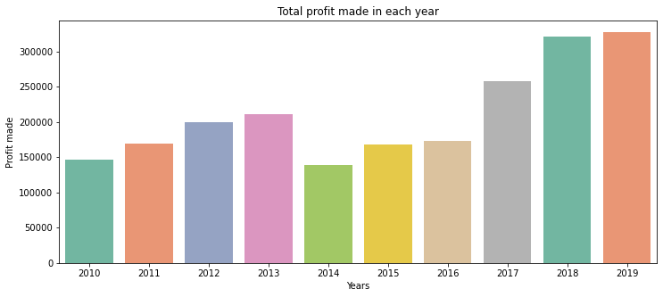

```python
plt.figure(figsize = (12,5))

year_analysis =sns.barplot(
    x = "year",
    y= "profit",
    data = df,
    estimator = sum,
    palette= sns.color_palette("Set2"),
    ci = None,


)

year_analysis.set(xlabel  = "Years", ylabel = "Profit made",title = "Total profit made in each year");
```

### Discount by Year

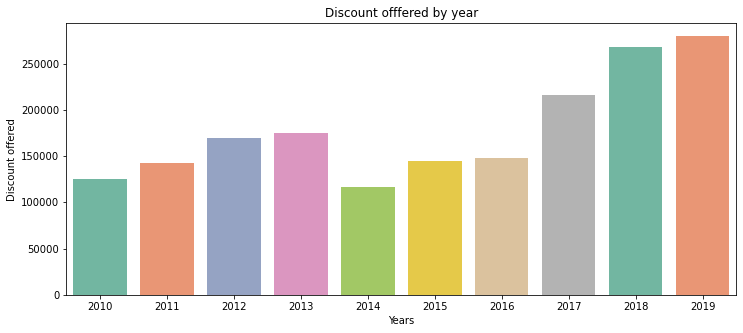

```python
plt.figure(figsize=(12,5))

year_analysis = sns.barplot(
    x = 'year',
    y = 'discount_amount',
    data = df,
    estimator = sum,
    palette = sns.color_palette("Set2"),
    ci = None,
)

year_analysis.set(xlabel = 'Years', ylabel = 'Discount offered', title='Discount offfered by year');
```

## 2) Month Analysis

### Bookings by Month

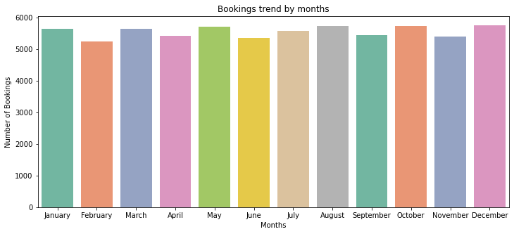

```python
plt.figure(figsize = (12,5))

month_analysis =sns.countplot(
    x = "month",
    data = df,
    palette= sns.color_palette("Set2")


);

month_analysis.set(xlabel  = "Months", ylabel = "Number of Bookings",title = "Bookings trend by months");
```

### Profit by month

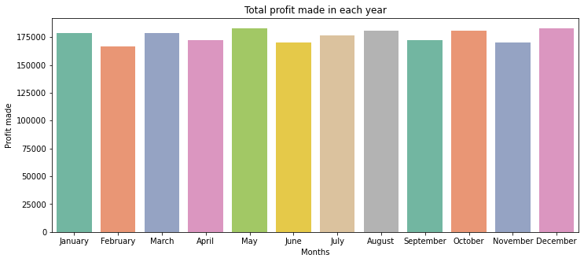

```python
plt.figure(figsize = (12,5))

month_analysis =sns.barplot(
    x = "month",
    y= "profit",
    data = df,
    estimator = sum,
    palette= sns.color_palette("Set2"),
    ci = None,


)

month_analysis.set(xlabel  = "Months", ylabel = "Profit made", title = "Total profit made in each year");
```

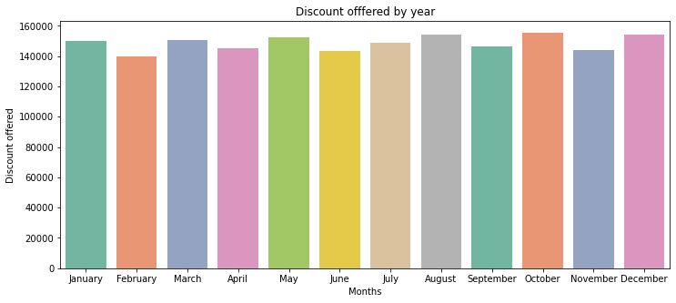

```python
plt.figure(figsize=(12,5))

month_analysis = sns.barplot(
    x = 'month',
    y = 'discount_amount',
    data = df,
    estimator = sum,
    palette = sns.color_palette("Set2"),
    ci = None,
)

month_analysis.set(xlabel = 'Months', ylabel = 'Discount offered', title='Discount offfered by year');
```

## 3) Hotel Analysis

### Top 5 Hotels by ratings

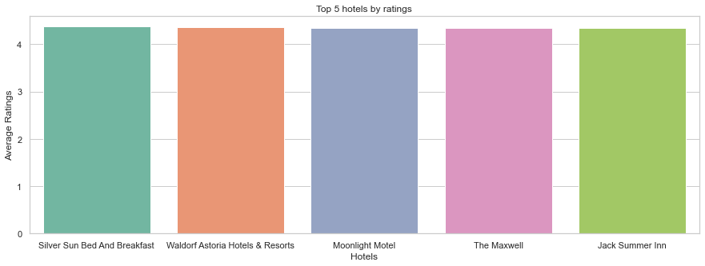

```python
plt.figure(figsize = (15,5))
sns.set_theme(style='whitegrid')
df_hotel = df.groupby('hotel_name', as_index=False)[['hotel_rating']].mean().sort_values('hotel_rating', ascending=False).head(5)
hotel_analysis = sns.barplot(
    x = "hotel_name",
    y = "hotel_rating",
    data = df_hotel,
    palette= sns.color_palette("Set2"),
    ci = None,


)

hotel_analysis.set(xlabel  = "Hotels", ylabel = "Average Ratings",title = "Top 5 hotels by ratings");
```

### Bottom 5 Hotels by Rating

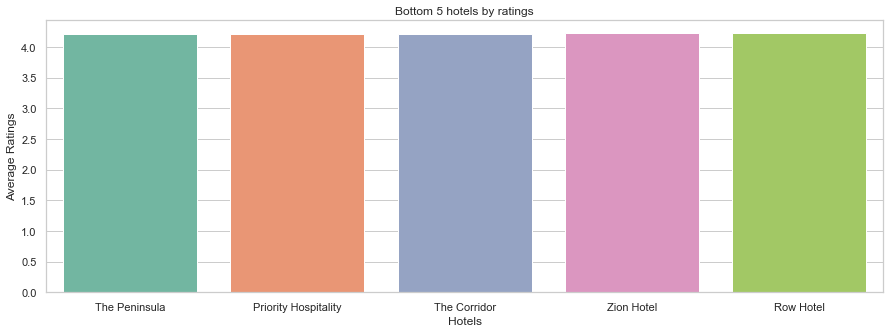

```python
plt.figure(figsize = (15,5))
sns.set_theme(style='whitegrid')
df_hotel = df.groupby('hotel_name', as_index=False)[['hotel_rating']].mean().sort_values('hotel_rating').head(5)
hotel_analysis = sns.barplot(
    x = "hotel_name",
    y = "hotel_rating",
    data = df_hotel,
    palette= sns.color_palette("Set2"),
    ci = None,


)

hotel_analysis.set(xlabel  = "Hotels", ylabel = "Average Ratings",title = "Bottom 5 hotels by ratings");
```

### Top 5 Hotels by bookings

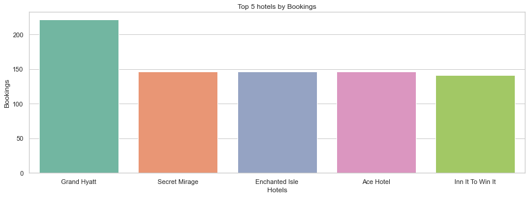

```python
plt.figure(figsize = (15,5))
sns.set_theme(style='whitegrid')
df_hotel = df.groupby('hotel_name', as_index=False)[['booking_id']].count().sort_values('booking_id', ascending=False).head(5)
hotel_analysis = sns.barplot(
    x = "hotel_name",
    y = "booking_id",
    data = df_hotel,
    palette= sns.color_palette("Set2"),
    ci = None,


)

hotel_analysis.set(xlabel  = "Hotels", ylabel = "Bookings",title = "Top 5 hotels by Bookings");
```

### Bottom 5 Hotels by bookings

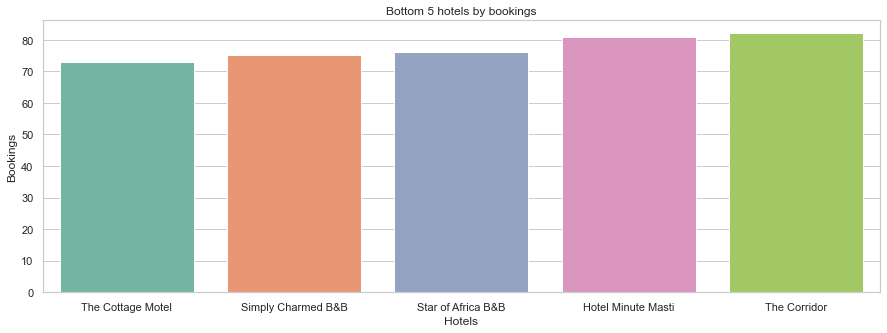

```python
plt.figure(figsize = (15,5))
sns.set_theme(style='whitegrid')
df_hotel = df.groupby('hotel_name', as_index=False)[['booking_id']].count().sort_values('booking_id').head(5)
hotel_analysis = sns.barplot(
    x = "hotel_name",
    y = "booking_id",
    data = df_hotel,
    palette= sns.color_palette("Set2"),
    ci = None,


)

hotel_analysis.set(xlabel  = "Hotels", ylabel = "Bookings",title = "Bottom 5 hotels by bookings");
```

### Top 5 Hotels by profits made

[figure not shown]

```python
plt.figure(figsize = (15,5))
sns.set_theme(style='whitegrid')
df_hotel = df.groupby('hotel_name', as_index=False)[['profit']].sum().sort_values('profit', ascending=False).head(5)
hotel_analysis = sns.barplot(
    x = "hotel_name",
    y = "profit",
    data = df_hotel,
    palette= sns.color_palette("Set2"),
    ci = None,


)

hotel_analysis.set(xlabel  = "Hotels", ylabel = "Profit Made",title = "Top 5 hotels by Profits made");
```

[figure not shown]

```python
plt.figure(figsize = (15,5))
sns.set_theme(style='whitegrid')
df_hotel = df.groupby('hotel_name', as_index=False)[['profit']].count().sort_values('profit').head(5)
hotel_analysis = sns.barplot(
    x = "hotel_name",
    y = "profit",
    data = df_hotel,
    palette= sns.color_palette("Set2"),
    ci = None,


)

hotel_analysis.set(xlabel  = "Hotels", ylabel = "Profits made",title = "Bottom 5 hotels by Profits made");
```

### Top 5 Hotels by discount offered

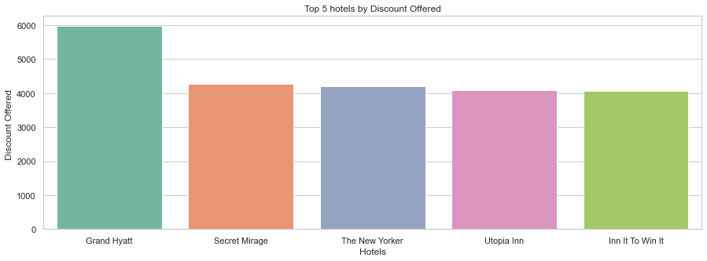

```python
plt.figure(figsize = (15,5))
sns.set_theme(style='whitegrid')
df_hotel = df.groupby('hotel_name', as_index=False)[['discount_amount']].sum().sort_values('discount_amount', ascending=False).head(5)
hotel_analysis = sns.barplot(
    x = "hotel_name",
    y = "discount_amount",
    data = df_hotel,
    palette= sns.color_palette("Set2"),
    ci = None,


)

hotel_analysis.set(xlabel  = "Hotels", ylabel = "Discount Offered ",title = "Top 5 hotels by Discount Offered");
```

[figure not shown]

```python
plt.figure(figsize = (15,5))
sns.set_theme(style='whitegrid')
df_hotel = df.groupby('hotel_name', as_index=False)[['discount_amount']].count().sort_values('discount_amount').head(5)
hotel_analysis = sns.barplot(
    x = "hotel_name",
    y = "discount_amount",
    data = df_hotel,
    palette= sns.color_palette("Set2"),
    ci = None,


)

hotel_analysis.set(xlabel  = "Hotels", ylabel = "Discount Offered ",title = "Bottom 5 hotels by Discount Offered");
```

## 4) Analysis by Destination Countries

### Bookings by Origin Country

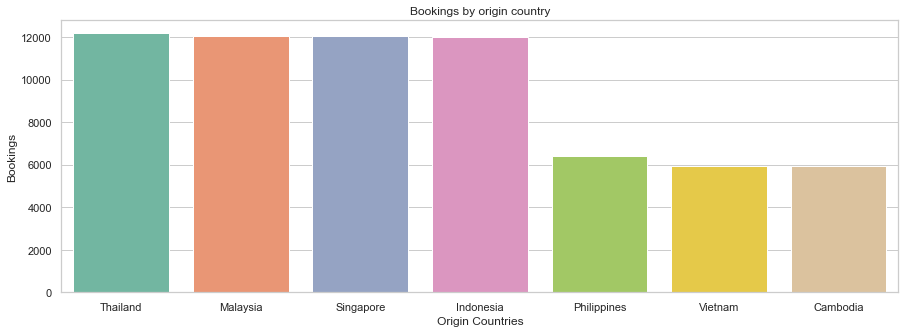

```python
plt.figure(figsize = (15,5))
sns.set_theme(style='whitegrid')
df_hotel = df.groupby('origin_country', as_index=False)[['booking_id']].count().sort_values('booking_id', ascending=False)
hotel_analysis = sns.barplot(
    x = "origin_country",
    y = "booking_id",
    data = df_hotel,
    palette= sns.color_palette("Set2"),
    ci = None,


)

hotel_analysis.set(xlabel  = "Origin Countries", ylabel = "Bookings", title = "Bookings by origin country");
```

### Bookings by Destination Countries

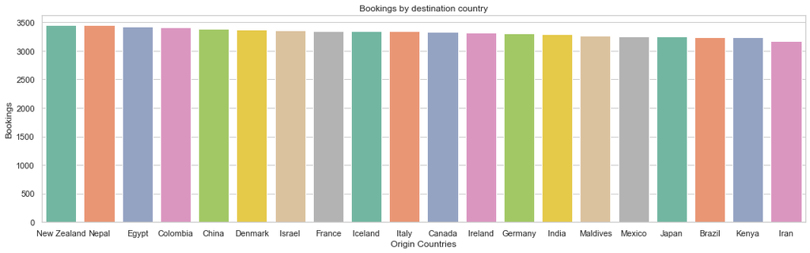

```python
plt.figure(figsize = (18,5))
sns.set_theme(style='whitegrid')
df_hotel = df.groupby('destination_country', as_index=False)[['booking_id']].count().sort_values('booking_id', ascending=False)
hotel_analysis = sns.barplot(
    x = "destination_country",
    y = "booking_id",
    data = df_hotel,
    palette= sns.color_palette("Set2"),
    ci = None,


)

hotel_analysis.set(xlabel  = "Origin Countries", ylabel = "Bookings", title = "Bookings by destination country");
```

# CONCLUSIONS

**Hotel**

- There was a general good rating by customers with the lowest being over 4.2.
- Silver sun bed and breakfast with the highest and Priority hospital and pennnisula being the lowest being priority and pennisula.
- Grand Hyatt was the most patronised and genrated the most profits, it also oferred the most discount.

**Gender**

- There was a balanced patronage, profits generated and discount offered to both genders.

**Payment options**

- There was a balanced patronage, profits generated and discount offered to all bank users and payMent options.

**Origin Country**

- The bulk of our customers are from Thailand, Malaysia and Singapore respectively.
- We have the least customers from Vietnam and Cambodia.

**Destination Country**

- We have an approximate equal distribution of our Customers destination country with New Zealand being the highest and Iran being the lowest

# RECOMMENDATIONS

- The reason for the trend disruption in 2013 and 2014 should bu investigated to avert future occurences
- Grand Hyatt should be monitored any observed cause of high patronage should be replicated in other hotels